# Allgemeine Aufgaben

# Allgemeine Aufgaben

## 1.

Um mit mit den Daten in R arbeiten zu können, müssen diese zuerst eingelesen und zusammengefügt werden. Außerdem muss die Spalte *Wareneingang* formatiert werden, damit sie im Datumsformat vorliegt.

```r
#Laden der nötigen Packages
library(readr)
library(dplyr)
```

```r
library(ggplot2)

# Einlesen der Datensätze
Logistikverzug_K7 <- read_csv2("Logistikverzug_K7.csv")
Komponente_K7 <- read_csv2("Komponente_K7.csv")
# Join der Datensätze
Logistikverzug <- inner_join(Komponente_K7, Logistikverzug_K7, by = "IDNummer")

# Formatieren der Spalte "Wareneingang" ins Datumsformat
Logistikverzug$Wareneingang <- as.Date(Logistikverzug$Wareneingang, format = "%d.%m.%Y")
```

Um das Verteilungsmodell des Logistikverzuges ermitteln zu können, wird zuerst der Vektor *Verzug* erstellt, der die Differenzen zwischen Warenausgang (also Produktionsdatum) und Wareneingang enthält. Danach werden die Daten zuerst einmal mittels eines Q-Q-Plots auf Normalverteilung überprüft. Dabei werden die Quantile der Daten (Sample Quantiles) gegen die theoretischen Quantile einer Normalverteilung (Theoretical Quantiles) geplottet. Ergibt sich dabei eine gerade Linie, kann man von einer Normalverteilung ausgehen. Da sich bei der Überprüfung auf Normalverteilung eine leicht exponentiell verlaufende Kurve der diskreten Niveaus ergibt, wird nun der Logarithmus der Daten auf Normalverteilung getestet. Hierbei sind die diskreten Niveaus der Daten in einer geraden Linie angeordnet, man kann also von einer Log-Normalverteilung ausgehen. Um die kürzeste und die längste Zeitspanne zwischen Warenausgang und Wareneingang herauszufinden, werden Minimum und Maximum des *Verzug*-Vektors ermittelt; der Mittelwert der Verteilung beträgt 5. Zur Visualisierung der Verteilung wird ein Histogramm und der Graph der Dichtefunktion erzeugt.

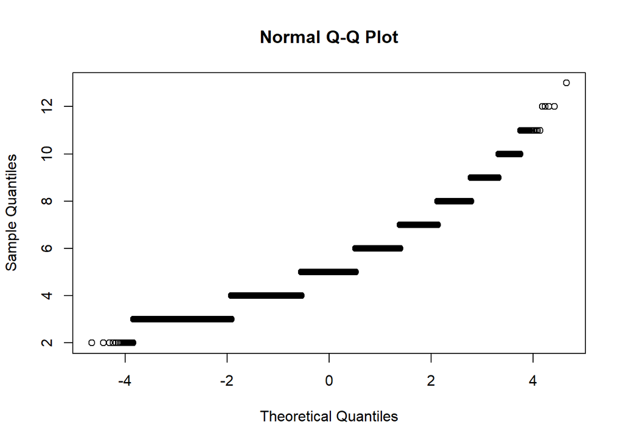

```r
# Erzeugen des Vektors "Verzug"
Verzug <- as.numeric(difftime(Logistikverzug$Wareneingang, Logistikverzug$Produktionsdatum, units = "days"))

# Q-Q-Plot Normalverteilung
qqnorm(Verzug)
```

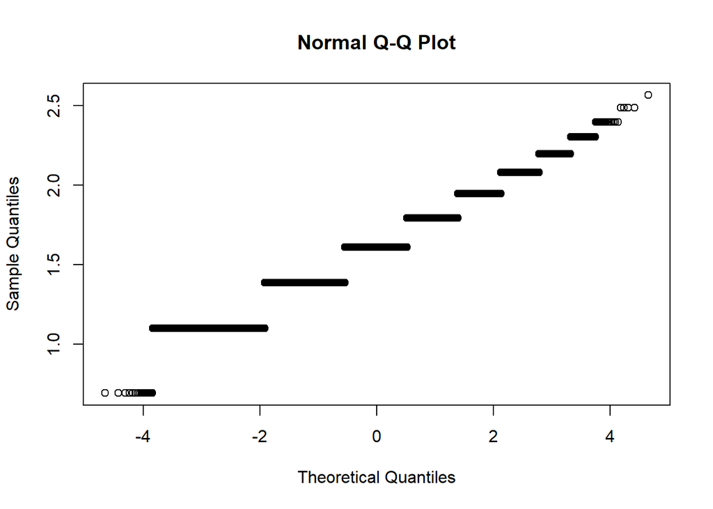

```r
# Q-Q-Plot Log-Normalverteilung
qqnorm(log(Verzug))
```

```r
# kürzeste Zeitspanne
min(Verzug)
```

```
## [1] 2
```

```r
# längste Zeitspanne
max(Verzug)
```

```
## [1] 13
```

```r
# Mittelwert der Verteilung
mean(Verzug)
```

```
## [1] 5.080437
```

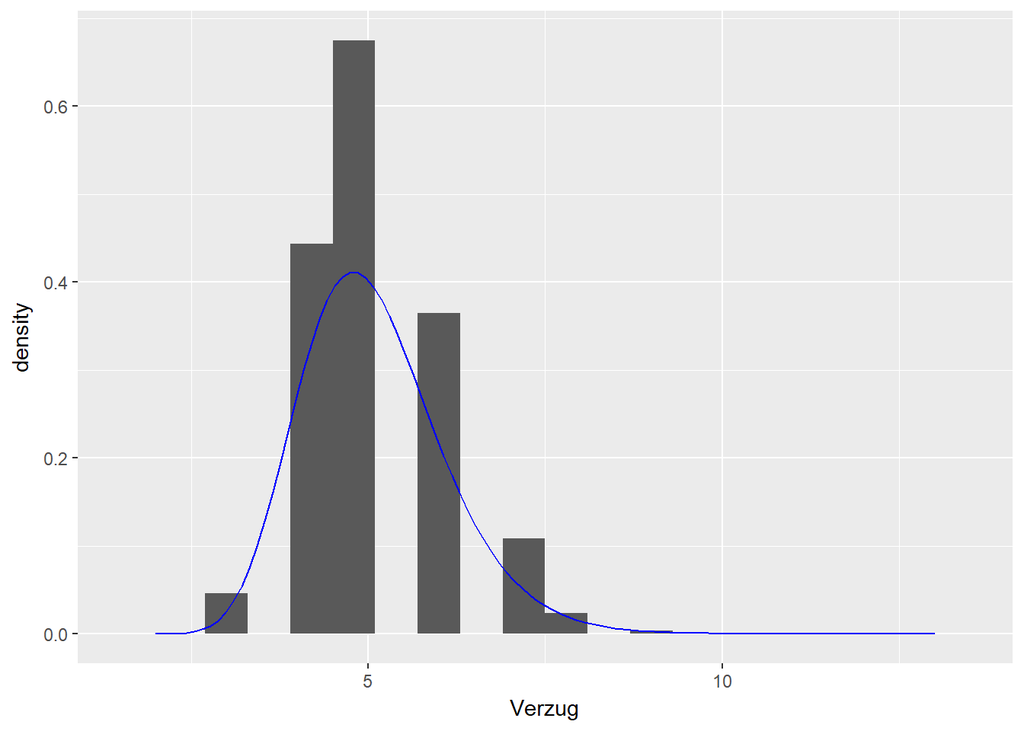

```r
# Darstellung der Verteilung
df <- data.frame(Verzug)
ggplot(df, aes(Verzug)) +
  geom_histogram(aes(y = ..density..), binwidth = 0.6) +
  stat_function(fun = dlnorm,
                args = list(meanlog = mean(log(df$Verzug)), sdlog = sd(log(df$Verzug))),
                col = 'blue')
```

## 2.

Bei gleichen Spaltennamen erhält die Spalte des ersten Datensatzes die Endung “.x”, die des zweiten Datensatzes die Endung “.y”.

```r
names(Logistikverzug)
```

```
##  [1] "X1.x"               "IDNummer"           "Produktionsdatum"
##  [4] "Herstellernummer.x" "Werksnummer.x"      "Fehlerhaft.x"
##  [7] "X1.y"               "Wareneingang"       "Herstellernummer.y"
## [10] "Werksnummer.y"      "Fehlerhaft.y"
```

## 3.

Mithilfe des `str`-Befehls kann man sich einen Überblick über den Datensatz verschaffen. Der Datensatz enthält 306490 Zeilen (“observations”) und 11 Spalten (“variables”). Da vier der Spalten doppelt auftreten, beschreibt der Datensatz folglich sieben Merkmale.

```r
str(Logistikverzug)
```

```
## Classes 'tbl_df', 'tbl' and 'data.frame':    306490 obs. of  11 variables:
##  $ X1.x              : int  1 2 3 4 5 6 7 8 9 10 ...
##  $ IDNummer          : chr  "K7-114-1142-1" "K7-114-1142-2" "K7-114-1142-3" "K7-114-1142-4" ...
##  $ Produktionsdatum  : Date, format: "2008-11-12" "2008-11-12" ...
##  $ Herstellernummer.x: int  114 114 114 114 114 114 114 114 114 114 ...
##  $ Werksnummer.x     : int  1142 1142 1142 1142 1142 1142 1142 1142 1142 1142 ...
##  $ Fehlerhaft.x      : int  0 0 0 0 0 0 0 0 0 0 ...
##  $ X1.y              : int  1 2 3 4 5 6 7 8 9 10 ...
##  $ Wareneingang      : Date, format: "2008-11-17" "2008-11-17" ...
##  $ Herstellernummer.y: int  114 114 114 114 114 114 114 114 114 114 ...
##  $ Werksnummer.y     : int  1142 1142 1142 1142 1142 1142 1142 1142 1142 1142 ...
##  $ Fehlerhaft.y      : int  0 0 0 0 0 0 0 0 0 0 ...
```

## 4.

Um die Effektivität des Joins beurteilen zu können, wird die Anzahl der Zeilen eines der Ausgangsdatensätze (da beide Augangsdatensätze die gleiche Zeilenanzahl haben) mit der Anzahl der Zeilen des gejointen Datensatzes verglichen.

```r
# Vergleich der Zeilenanzahl
nrow(Logistikverzug) / nrow(Komponente_K7)
```

```
## [1] 1
```

Das Verhältnis zwischen den Zeilenzahlen beträgt 1. Dementsprechend liegt die Effektivität des Joins bei 100%.